# NOAA_Storm_Analysis

# Results: Creating Visualizations:

# Plot for Health Impact (Fatalities)

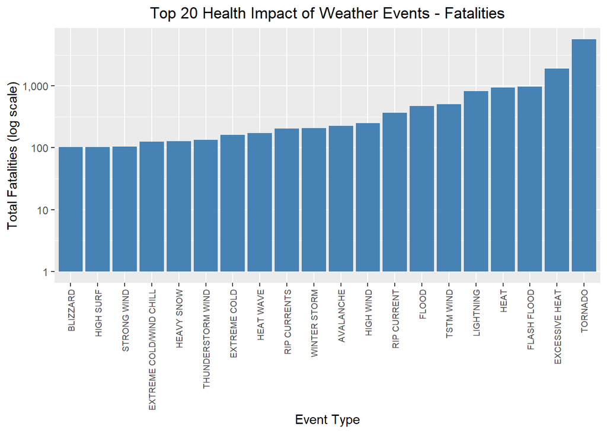

```r
# Adding a small constant to fatalities to avoid log(0)
health_impact$Total_Fatalities <- health_impact$Total_Fatalities + 1

# Now let's create the plot limiting to the top N event types to avoid clutter
top_n <- 20 # for example, the top 20 event types
health_impact_top_n <- health_impact %>%
  top_n(top_n, wt = Total_Fatalities)

ggplot(health_impact_top_n, aes(x = reorder(EVTYPE, Total_Fatalities), y = Total_Fatalities)) +
  geom_bar(stat = "identity", fill = "steelblue") +
  scale_y_log10(labels = scales::comma) +
  theme(axis.text.x = element_text(angle = 90, vjust = 0.5, hjust=1, size = 7),
        plot.title = element_text(hjust = 0.5)) +
  labs(title = "Top 20 Health Impact of Weather Events - Fatalities",
       x = "Event Type",
       y = "Total Fatalities (log scale)")
```

# Plot for Health Impact (Injuries)

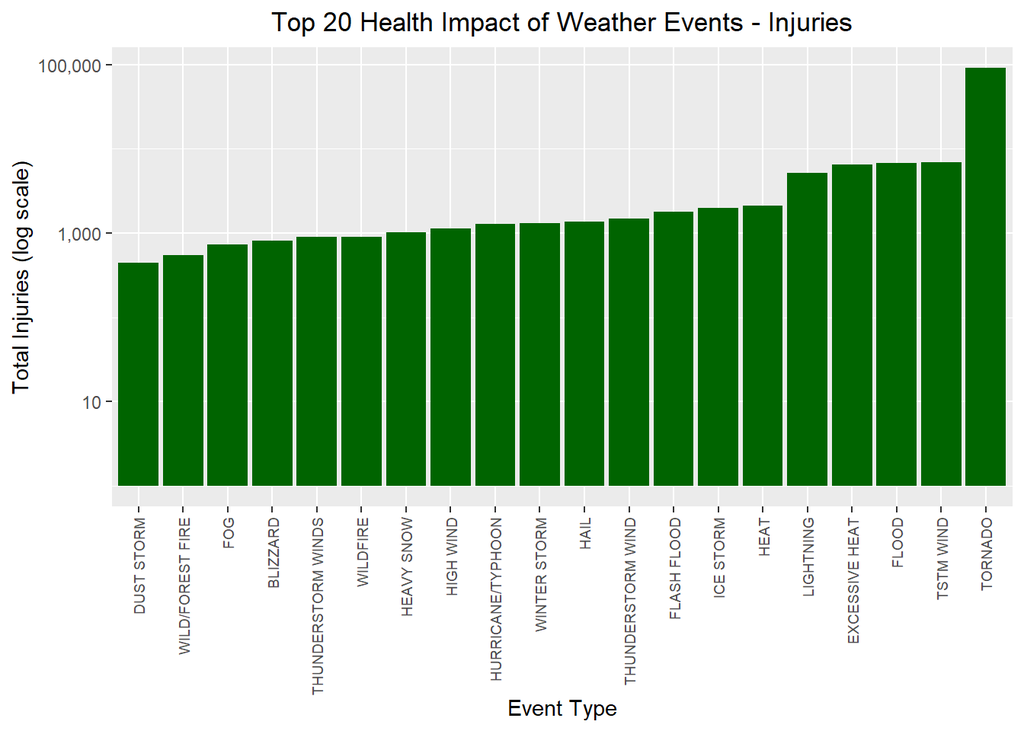

```r
# Add a small constant to the injuries count to handle zeroes
health_impact$Total_Injuries <- health_impact$Total_Injuries + 1

# Limit to top event types for clarity
health_impact_top_n <- health_impact %>%
  top_n(top_n, wt = Total_Injuries)

# Create the plot for Injuries
ggplot(health_impact_top_n, aes(x = reorder(EVTYPE, Total_Injuries), y = Total_Injuries)) +
  geom_bar(stat = "identity", fill = "darkgreen") +
  scale_y_log10(labels = scales::comma) +
  theme(axis.text.x = element_text(angle = 90, vjust = 0.5, hjust=1, size = 7),
        plot.title = element_text(hjust = 0.5)) +
  labs(title = "Top 20 Health Impact of Weather Events - Injuries",
       x = "Event Type",
       y = "Total Injuries (log scale)")
```

# Plot for Economic Impact (Property Damage)

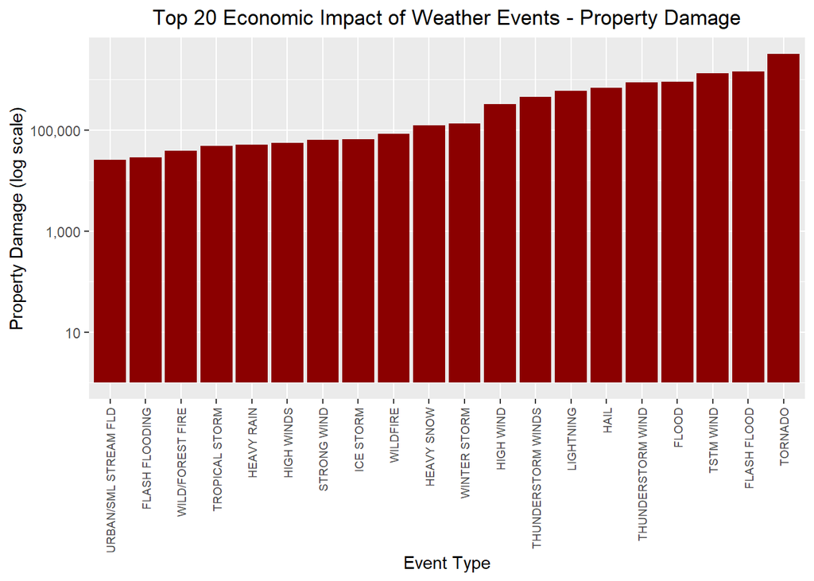

```r
# Add a small constant to the damage amounts to handle zeroes
economic_impact$Property_Damage <- economic_impact$Property_Damage + 1

# Limit to top event types for clarity
top_n <- 20
economic_impact_top_n <- economic_impact %>%
  top_n(top_n, wt = Property_Damage)

# Create the plot for Property Damage
ggplot(economic_impact_top_n, aes(x = reorder(EVTYPE, Property_Damage), y = Property_Damage)) +
  geom_bar(stat = "identity", fill = "darkred") +
  scale_y_log10(labels = scales::comma) +
  theme(axis.text.x = element_text(angle = 90, vjust = 0.5, hjust=1, size = 7),
        plot.title = element_text(hjust = 0.5)) +
  labs(title = "Top 20 Economic Impact of Weather Events - Property Damage",
       x = "Event Type",
       y = "Property Damage (log scale)")
```

To reiterate, the analysis of the NOAA Storm Database has brought to light the specific weather events that historically have had the most significant impact on human health and economic conditions. By leveraging this data, stakeholders can better allocate resources, enhance preparedness protocols, and implement more effective response strategies to mitigate the adverse effects of severe weather phenomena.